# Double Burden of Water and Sanitation Inequality in Colombia

Daniella Díaz

2025-07-04

# Introduction

Access to improved drinking water and sanitation is a fundamental human right and a key social determinant of health. However, disparities in access persist within many countries, including Colombia.

This project explores the “double burden” of poor access to both improved drinking water and sanitation in Colombia, focusing on how these forms of deprivation vary by residence (urban/rural), wealth, and region. Understanding these inequalities is essential for designing targeted interventions to improve health outcomes and reduce WASH-related vulnerabilities among women in reproductive age.

This analysis utilizes the Colombia Demographic and Health Survey (DHS) datase. Likewise, “poor water” and “poor sanitation” are defined based on categories reflecting unimproved or inadequate services, following WHO/UNICEF Joint Monitoring Programme (JMP) classifications and the available DHS variables.

# Wealth per Region

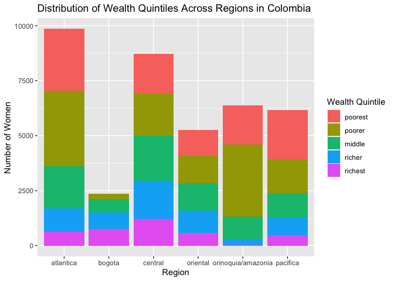

The plot demonstrates clear regional disparities in wealth distribution among women in Colombia. Regions like Atlantic, Pacifica and Orinoquia/Amazonia exhibit higher proportions of women in lower wealth quintiles, while Bogotá shows a concentration in richer quintiles.

# Poor Water and Poor Sanitation

Poor water includes reliance on rainwater, tanker trucks, carts with small tanks, rivers/streams/springs, open wells without pumps, other unimproved sources, and cases where respondents are not de jure residents.

Poor sanitation includes no toilet facility, traditional pit toilets, traditional toilets discharging to sea/river, other unimproved facilities, and cases where respondents are not de jure residents.

A double burden indicator was created to identify households simultaneously experiencing poor water and poor sanitation conditions.

# Poor Water by Wealth and Residence

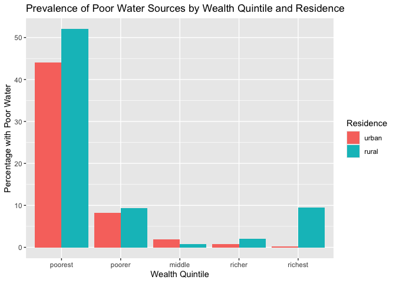

# Poor Sanitation per Wealth and Residence

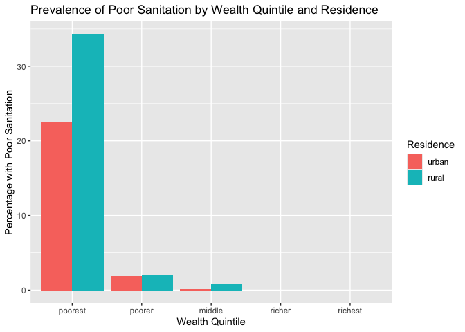

Analysis of poor water and sanitation access across wealth quintiles and residence reveals socioeconomic and geographic disparities in Colombia.

Among the poorest quintile, poor water access affects 45% of urban women and over 50% of rural women, while poor sanitation impacts 23% of urban women and approximately 34% of rural women. This indicates that rural women in the poorest quintile face a compounded burden of inadequate water and sanitation access, placing them at elevated health and social risk.

As wealth increases, the prevalence of poor water and sanitation declines sharply. In the poorer quintile, poor water access drops to around 8–10%, and poor sanitation to 2–3% across residences. In the middle and richer quintiles, prevalence of poor water falls to around 1–3% while poor sanitation is nearly absent. In the richest quintile, poor water access persists at around 9–10% among rural women while remaining nearly zero in urban areas, whereas poor sanitation is virtually nonexistent across both residences.

# Poor Water by Region

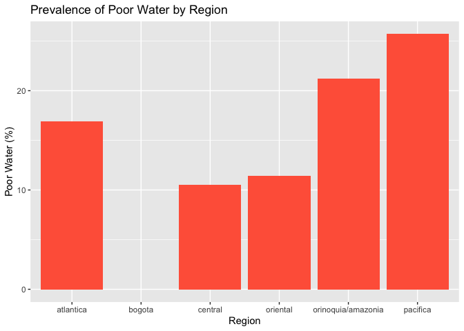

# Poor Sanitation by Region

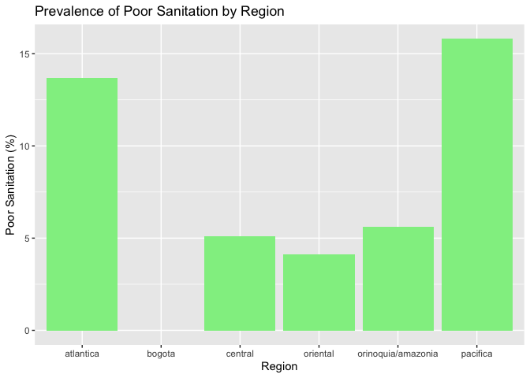

Poor water access is highest in the Pacifica region (~25%), followed by Orinoquia/Amazonia (~21%) and Atlantica (~17%). The Central and Oriental regions report moderate levels (~10–12%), while Bogotá demonstrates near-universal water access with 0% reporting poor water sources.

Similarly, poor sanitation is most prevalent in Pacifica (15.8%) and Atlantica (13.7%), with moderate prevalence in Orinoquia/Amazonia (5.6%) and Central (5.1%), and the lowest in Oriental (4.1%). Bogotá again shows complete coverage, with 0% reporting poor sanitation.

These findings indicate that the Pacifica, Orinoquia/Amazonia, and Atlantica regions consistently experience higher burdens of inadequate water and sanitation access, while Bogotá demonstrates effective WASH infrastructure coverage.

# Doublen Burden by Wealth and Residence

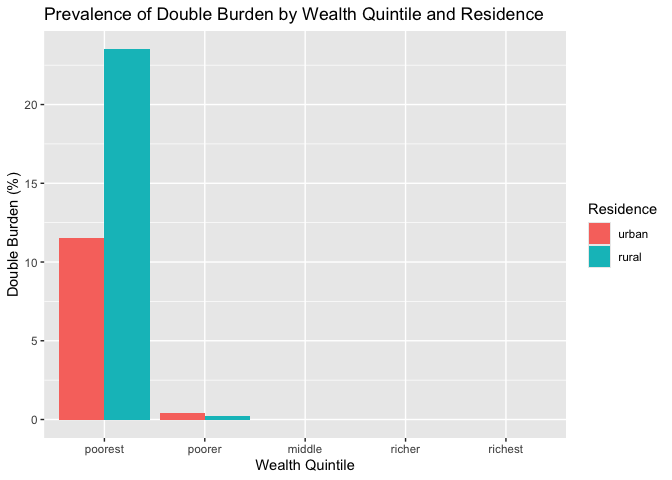

The plot illustrates the prevalence of the double burden of poor water and sanitation across wealth quintiles, disaggregated by residence (urban and rural) in Colombia.

A marked disparity is evident in the poorest wealth quintile, where 23.5% of rural women and 11.5% of urban women experience the double burden. This highlights the compounded disadvantage faced by the rural poor in accessing adequate water and sanitation services.

In contrast, the prevalence sharply decreases in the poorer quintile, where only 0.4% of urban women and 0.2% of rural women experience the double burden. For the middle, richer, and richest quintiles, the prevalence is 0% across both urban and rural settings, indicating that as wealth increases, the likelihood of experiencing simultaneous deprivation in water and sanitation disappears.

These findings emphasize the intersection between poverty and rural residence as key determinants of the double burden, underscoring the need for targeted WASH interventions prioritizing the rural and urban poorest populations in Colombia.

# Doublen Burden by Wealth, Residence and Region

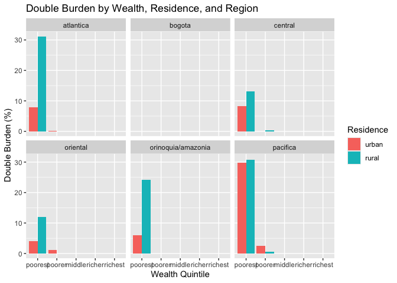

This graph presents the prevalence of the double burden of poor water and sanitation across wealth quintiles and residence types, faceted by region. The visualization allows for the comparison of double burden prevalence across regions while highlighting differences by wealth and residence within each region. Regions with higher concentrations of poorer and rural populations exhibit higher double burden rates, emphasizing the compounded effects of regional, economic, and geographic disparities.

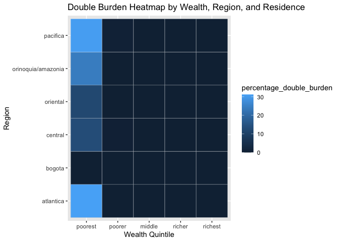

Time to Water Collection Among Women in Colombia

| time_to_water | n | percent | valid_percent |
| --- | --- | --- | --- |
| On premises | 36,398 | 94.0% | 94.3% |
| < 15 min | 1,203 | 3.1% | 3.1% |
| 15-30 min | 707 | 1.8% | 1.8% |
| > 30 min | 308 | 0.8% | 0.8% |
|  | 102 | 0.3% | - |

The table shows that 94% of women in Colombia report having water on premises, indicating widespread household water access nationally. However, 3.1% of women spend less than 15 minutes collecting water, while 1.8% spend 15–30 minutes, and 0.8% spend more than 30 minutes collecting water.

Although these percentages are small, they represent thousands of women experiencing daily time burdens to access water, with potential impacts on health, productivity, and education. The near-universal access contrasts with regional and wealth disparities observed in water quality, suggesting that while water is available on premises for most, issues of water quality and sanitation access remain critical dimensions of WASH inequalities in Colombia.

# Conclusion

This analysis of the Colombia DHS dataset reveals substantial disparities in access to improved water and sanitation across wealth quintiles, residence types, and regions.

Among the poorest quintile, over 50% of rural women and 45% of urban women lack access to improved water sources, while 34% of rural and 23% of urban women lack adequate sanitation, illustrating a compounded WASH burden on the rural poor. As wealth increases, the prevalence of poor water and sanitation declines sharply, with near-universal coverage in the richest quintile across urban settings.

Regionally, the Pacifica region exhibits the highest prevalence of poor water access (25%) and poor sanitation (15.8%), followed by Atlantica (17% poor water, 13.7% poor sanitation) and Orinoquia/Amazonia (21% poor water, 5.6% poor sanitation). In contrast, Bogotá demonstrates 0% prevalence for both indicators, reflecting its effective WASH infrastructure.

These findings highlight clear socioeconomic and geographic inequalities, with the poorest and rural populations, particularly in Pacifica, Atlantica, and Orinoquia/Amazonia, experiencing the highest burdens of inadequate water and sanitation access. Targeted interventions prioritizing these populations are critical to reducing WASH-related health disparities and advancing equitable access to essential services in Colombia.